# Building a machine learning model for Human Activity Recognition

Success Moses(msucc2024@gmail.com)

2024-09-04

## Synopsis

In this project, I developed a machine learning model to classify human activities using accelerometer data collected from multiple body positions (belt, forearm, arm, and dumbbell). The dataset includes time-series sensor readings, which present a challenging problem for accurate classification.

### Required Libraries

```r
library(data.table)
library(randomForest)
library(dplyr)
library(caret)
library(knitr)
library(kableExtra)
```

## Reading the data and features selection

```r
data = fread('pml-training.csv', string=TRUE)
```

## Exploratory Data Analysis

```r
dim(data)
```

```
[1] 19622   160
```

There are a `19622` rows and `160` columns in the training data set. The dataset is probably very dirty and contains a lot of missing values. I may need to clean up the data. Below I display the names of every column in the entire data set using `||` as a seperator.

```r
colnames = names(data)
paste(colnames, collapse=' || ')
```

[output not shown]

The dataset contains the variable, `classe`, I am trying to predict, therefore I am going to be using a supervised learning algorithm. Columns `V1`, `user_name`, `raw_timestamp_part_1`, `raw_timestamp_part_2`, `cvtd_timestamp`, `new_window`, `num_window`, are provide description like timestamps, windows, usernames, etc. They are not going to be useful for prediction, I would need to remove them before feeding to the learning algorithm.

```r
mean(is.na(data))
```

```
[1] 0.6131835
```

The code above calculate the proportion of missing values in the data. There a lot of missing values. Missing values can affect the performance of a learning algorithm. The strategy I will use to fill in missing values is by removing features that contains a lot of missing values.

```r
names(which(sapply(data, anyNA))) %>% paste(collapse = ' || ')
```

[output not shown]

The code above lists the columns containing missing values. Looking at the output, most of the ‘bad’ column contains words like ‘min’, ‘max’, ‘avg’, ‘var’, ‘stddev’, ’skewness, etc. These bad columns likely represent summary measures, aggregated over windows of time, which explains the high number of missing values. Since these features are not directly useful for prediction, I will remove them, ensuring that the machine learning algorithm can focus on more relevant data.

## Features Selection

```r
char = '^min|^max|^avg|^var|^stddev|^skewness|^kurtosis|^amplitude'
bad = grep(char, names(data))
bad = c(bad, 1:7)
data = data[, -(..bad)]

nearZeroVar = nearZeroVar(data)
data = data[, -(..nearZeroVar)]
data = na.omit(data)
```

## Features Plot

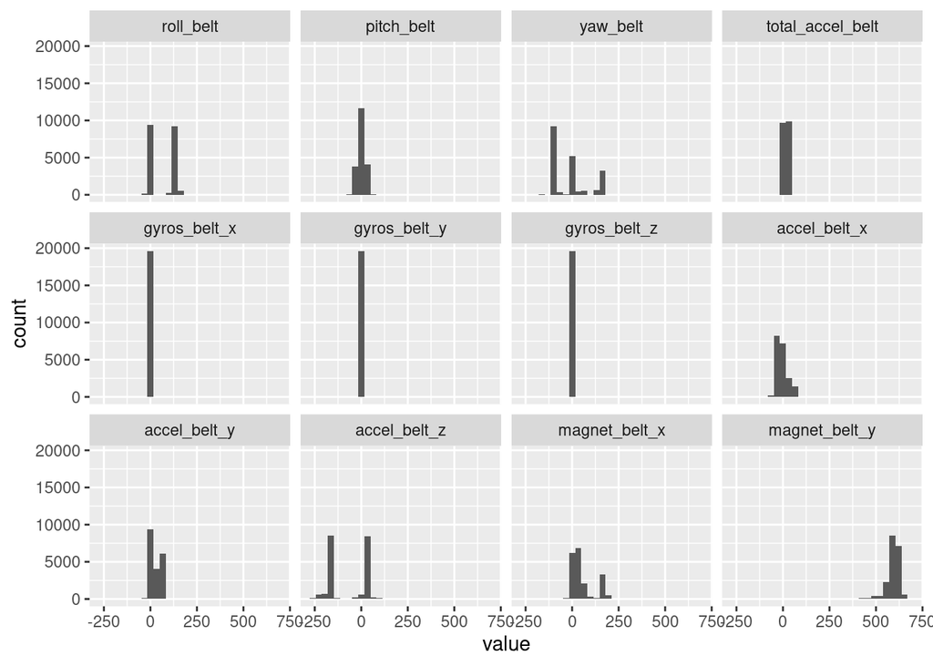

```r
data_melted = melt(data, id.vars = 'classe')
subset_data_melted = filter(data_melted, as.numeric(variable) %in% 1:12)
g = ggplot(subset_data_melted, aes(value))

g + geom_histogram() + facet_wrap(vars(variable))
```

The above plot shows histograms of selected features from the dataset. These features display significant deviations from normality, making traditional statistical methods like linear discriminant analysis and logistic regression less effective. However, machine learning techniques such as random forests and gradient-boosted trees are more likely to perform well with this type of data.

## Training

The classification algorithm will be built using random forest. I set the `ntree` parameter to `100`. I also split the data set into `trainData` and `testData`. I would use `testData` to perform out-of-sample test for the model.

```r
inTrain = createDataPartition(
  y = data$classe,
  p=0.5,
  list = FALSE
)

# Create partitions of the original data set
trainData = data[inTrain,] ; testData = data[-inTrain,]

# Using random forest to create classification algorithm
fit = randomForest(data=trainData, classe~., ntree=100)

pred = predict(fit, testData)
true = testData$classe

x = confusionMatrix(pred, true)
accuracy <- x$overall %>% as.data.frame

kable(accuracy,
      caption = "Accuracy Table",
      format = 'html',
      align = 'c'
      ) %>%
  kable_styling(full_width = FALSE, position = "center") %>%
  column_spec(1, width = "5cm") %>%
  column_spec(2, width = "5cm")
```

Accuracy Table

|  | . |
| --- | --- |
| Accuracy | 0.9904179 |
| Kappa | 0.9878781 |
| AccuracyLower | 0.9882866 |
| AccuracyUpper | 0.9922500 |
| AccuracyNull | 0.2844037 |
| AccuracyPValue | 0.0000000 |
| McnemarPValue | NaN |